# Model for Limited Efforts

Hongyi Xu - Stockholm School of Economics

6/16/2022

> Things to notice:  
> 1. The entrepreneur will always have $2A$ at the beginning of each period.  
> 2. Whether self-financing is allowed is undetermined.  
> 3. Starting with $2A$ assets will alter the region in 1.3 What if the Bad Type Mimics the Good Type?.

#### 1. Math Model

Following the logic presented in the previous file, we can build up the mathematical model.

##### 1.1 General Assumptions

Denote the two independent and identical projects as $a$ and $b$ and the entity combining two projects is called “the company”. The effort level of the entrepreneur is denoted as $E$. We set $E \in \{0,1\}$ when the entrepreneur runs only one project and $E=1$ means that the entrepreneur exerts high effort, while $E=0$ means the entrepreneur shirks. And $E \in \{0, 1, 2\}$ when the entrepreneur manages the company with each value corresponding to shirk on both projects, exert efforts on only one projects and exert efforts on both projects. The asset contributed by the entrepreneur to each project is $A \geq \bar{A} = I - p_H(R - \frac{B}{\Delta p})$ and the total investment for each project if $I$. *At the beginning of each period, the entrepreneur will be given wealth $2A$, which can be used for project investments or consumption. And at the end of each period, the entrepreneur will consume all payoffs and leave nothing to the next period.* In addition, for each project, the probability of success and generating cash flow $R$ is $p_H$ when the entrepreneur exerts effort on that project and $p_L$ if the entrepreneur shirks. And $p_H R \geq I \geq p_L R$. The private benefit for the entrepreneur in this case equals to $B(2-E)$ when $E \in \{0,1,2\}$.

The entrepreneur can be either a Good type or a Bad type. The difference is that the Good type does not have an upper bound for the effort level $E$, while the Bad type has an upper bound $\bar{E}$ such that $E \leq \bar{E}$. For simplicity, we set $\bar{E}=1$ meaning that the Bad type entrepreneur can only exert efforts on maximum one project. But for the Good type, she can choose to exert efforts on both projects. Meanwhile, we assume that a signal $X_0$, which is the only information regarding the company operation, will be received at the end of period 1. And we define $X_0$ as the success and failure outcome of each project. The investors with a prior - the probability of the entrepreneur being a Good type - can update their beliefs conditional on the signal $X_0$ they received at the end of period 1. And they will use the posterior to judge whether the entrepreneur is still a Good type or should be identified as a Bad type. (*Practically, the judgement can be subject to the posterior and some exogenous thresholds*.)

The whole projects live for two periods - period 1 and period 2. At the beginning of each period, the entrepreneur needs to seek financing for the company/projects. In period 1, she needs to decide whether she wants to diversify by adding project $b$ and operate the new company as a combination of project $a$ and $b$. And in period 2, she needs to decide whether to keep company’s current structure, or conduct a corporate spin-off, breaking the company into two new entities based upon project $a$ and $b$.

##### 1.2 When Does the Entrepreneur Choose to Diversify?

The decision of diversification depends on two factors. First, whether the manager can achieve a higher utility by diversification. Second, whether the company after the diversification can receive external financing from investors.

For the first factor, we know that the entrepreneur’s utility is $p_H R-I+A$ when managing only project $a$. So the diversification will happen if and only if the utility from managing the company is higher than that from managing project $a$. If the entrepreneur is a Good type and investors identify she as a Good type, from the analysis in Tirole (2006), we know that the entrepreneur’s utility will be $2(p_H - I + A)$ with the optimal contract $R_b = \{R_2, 0, 0\}$ corresponding to cash flow outcomes $\{2R,R,0\}$. We, however, are interested in the case that the entrepreneur is a Bad type and is misidentified by investors as a Good type. We are trying to find out the necessary conditions for the entrepreneur choosing to diversify.

> PS: The case that the entrepreneur is a Bad type and investors correctly identify her type is discussed in the case in period 2.

This question can be set up like this, under the assumption that $E=1$ is the entrepreneur’s optimal action,
$$\max_{R_b(r)} \sum_{r \in \Omega} R_b(r) \color{red}{\mathbf{P}(r | E =
1)} + \color{red}{B} \quad \text{ s.t. }$$
$$\text{(PC)} \quad \sum_{r \in \Omega} (r - R_b(r)) \mathbf{P}(r | E = 2)
\geq 2 (I - A) \tag{16}$$
$$\text{(} \text{IC}_1 \text{)} \quad \sum_{r \in \Omega} R_b(r)
\mathbf{P}(r | E = 2) \geq
\sum_{r \in \Omega} R_b(r) \mathbf{P}(r | E = 1) + B \tag{17}$$
$$\text{(} \text{IC}_2 \text{)} \quad \sum_{r \in \Omega} R_b(r)
\mathbf{P}(r | E = 2) \geq
\sum_{r \in \Omega} R_b(r) \mathbf{P}(r | E = 0) + 2B \tag{18}$$

And we can write out the Lagrangian as

$$\mathcal{L} = \sum_{r \in \Omega} R_b(r) \mathbf{P}(r | E = 1) + B +
\lambda_{PC} \Big \{ \sum_{r \in \Omega} (r - R_b(r)) \mathbf{P}(r | E =
2) - 2 (I - A) \Big \}$$
$$+ \lambda_{IC1} \Big \{ \sum_{r \in \Omega} R_b(r) \big [\mathbf{P}(r |
E = 2) - \mathbf{P}(r | E = 1) \big ] - B
\Big \}$$
$$+ \lambda_{IC2} \Big \{ \sum_{r \in \Omega} R_b(r) \big [\mathbf{P}(r |
E = 2) - \mathbf{P}(r | E = 0) \big ] - 2B
\Big \} \tag{19}$$

FOC:
$$\frac{\partial \mathcal{L}}{\partial R_b(r)} = \mathbf{P}(r|E=1) -
\lambda_{PC} \big \{ \mathbf{P}(r|E=2) \big \}
+ \lambda_{IC1} \big \{ \mathbf{P}(r|E=2) - \mathbf{P}(r|E=1) \big \}$$
$$+ \lambda_{IC2} \big \{ \mathbf{P}(r|E=2) - \mathbf{P}(r|E=0) \big \} =
0, \quad \forall r \in \{2R, R, 0\} \tag{20}$$
From the FOC we can see that if (PC) does not bind, we must have $\lambda_{PC} = 0$ and we have $\frac{\partial \mathcal{L}}{\partial R_b(r)} > 0$ for all potential contract $R_b \in [0, 2R] \times [0, R] \times \{0\}$. Therefore, (PC) must bind. Then, does the contract in the form of $\{R_2, 0, 0\}$ solve the question? No, it will not satisfy the FOC condition. And the only solution we can find is the optimal contract in the form of $R_b' = \{R_2, R_1, 0\}$, where
$$R_2 = 2R - \frac{2(I-A) - (R - R_1) \mathbf{P}(R | E = 2)}{\mathbf{P}(2R
| E = 2)} \quad \text{ and } \quad
R_1 = \min \big \{ R_1^1, R_1^2 \big \}$$
with $R_1^1$ coming from binding both (PC) and (IC<sub>1</sub>) and $R_1^2$ coming from binding both (PC) and (IC<sub>2</sub>) constraints. Previous graphical presentation will be an intuitive way to verify the this contract.

Meanwhile, we can set up the question when shirking on both projects (i.e. $E = 0$) being the optimal action for the entrepreneur as
$$\max_{R_b(r)} \sum_{r \in \Omega} R_b(r) \color{red}{\mathbf{P}(r | E =
0)} + \color{red}{2B} \quad \text{ s.t. }$$
$$\text{(PC)} \quad \sum_{r \in \Omega} (r - R_b(r)) \mathbf{P}(r | E = 2)
\geq 2 (I - A) \tag{21}$$
$$\text{(} \text{IC}_1 \text{)} \quad \sum_{r \in \Omega} R_b(r)
\mathbf{P}(r | E = 2) \geq
\sum_{r \in \Omega} R_b(r) \mathbf{P}(r | E = 1) + B \tag{22}$$
$$\text{(} \text{IC}_2 \text{)} \quad \sum_{r \in \Omega} R_b(r)
\mathbf{P}(r | E = 2) \geq
\sum_{r \in \Omega} R_b(r) \mathbf{P}(r | E = 0) + 2B \tag{23}$$
Undergoing the same procedure, we can verify that $R_b' = \{R_2, R_1, 0\}$ will be the optimal contract given $E=0$ being entrepreneur’s optimal action. Therefore, $R_b' = \{R_2, R_1, 0\}$ will the optimal contract, regardless of the optimal action for a Bad type entrepreneur in this case. And with this unique contract, we can define the optimal action of the entrepreneur is
$$E^* = \arg \max_{E \in \{0,1\}} \sum_{r \in \Omega} R_b'(r)
\mathbf{P}(r | E) + (2-E)B.$$
We can see that $E^* = 1$ if
$$\sum_{r \in \Omega} R_b'(r) \mathbf{P}(r | E = 1) + B \geq \sum_{r
\in \Omega} R_b'(r) \mathbf{P}(r | E = 0) + 2B$$
$$\iff \sum_{r \in \Omega} R_b'(r) \mathbf{P}(r | E = 2)
\frac{\mathbf{P}(r | E = 1) - \mathbf{P}(r | E = 0)}{\mathbf{P}(r | E =
2)}$$
$$= \sum_{r \in \Omega} R_b'(r) \mathbf{P}(r | E = 2) \Bigg [ -
\frac{\mathbf{P}(r | E = 2) - \mathbf{P}(r | E = 1)}{\mathbf{P}(r | E =
2)} + \frac{\mathbf{P}(r | E = 2) - \mathbf{P}(r | E = 0)}{\mathbf{P}(r
| E = 2)} \Bigg ] \geq B \tag{23}$$
Since the optimal contract satisfies (PC), (IC<sub>1</sub>) and (IC<sub>2</sub>) constraints, we can get from (IC<sub>1</sub>) and (IC<sub>2</sub>) that
$$\sum_{r \in \Omega} R_b'(r) \mathbf{P}(r | E = 2) \Bigg
[\frac{\mathbf{P}(r | E = 2) - \mathbf{P}(r | E = 1)}{\mathbf{P}(r | E =
2)} \Bigg ] \geq B$$
$$\text{and } \sum_{r \in \Omega} R_b'(r) \mathbf{P}(r | E = 2) \Bigg
[\frac{\mathbf{P}(r | E = 2) - \mathbf{P}(r | E = 0)}{\mathbf{P}(r | E =
2)} \Bigg ] \geq 2B.$$
And if $R_1 = R_1^1 \leq R_1^2$, then we know (PC) and (IC<sub>1</sub>) bind but (IC<sub>2</sub>) does not. And bring this information back to Eq (23), we know that the inequality holds and $E^* = 1$ is the optimal action to the entrepreneur. And if And if $R_1 = R_1^2 > R_1^1$, meaning that (PC) and (IC<sub>2</sub>) bind but not (IC<sub>1</sub>), we can see that the inequality does not hold and $E^* = 0$.

Please note that although the exact action chosen by the entrepreneur in period 1 will alter the distribution of the cash flow outcome and the signal $X_0$, it won’t impact investors’ financing decisions as long as they still identify the entrepreneur as a Good type.

> This may come into play when we switch from a binary identification process to a more realistic case. In that scenario, we consider investors will incorporate their subjective beliefs on the type of the entrepreneur into forming the financial contract.

##### 1.3 What if the Bad Type Mimics the Good Type?

In the previous analysis, we can see that both contract $R_b = \{R_2, 0, 0\}$ and $R_b' = \{R_2, R_1, 0\}$ (*Sorry for abusing the variable here. Just be clear that the $R_2$ term in the two contracts are not the same in value.*) are optimal contracts for a Good type entrepreneur. While, only the latter, $R_b'$, is optimal to the Bad type entrepreneur. Therefore, the Good type should always choose $R_b$ as a way to signal her type, conditional on all entrepreneurs maximizing their objective functions. So, the sensible thing for a Bad type entrepreneur to do is to mimic the optimal contract of the Good type entrepreneur $R_b$.

Now the question turns into

1. what is the necessary condition for the entrepreneur choosing to diversify?
2. what is the optimal action of the entrepreneur, if the diversification proceeds?

For the first question, the contract proposed by a Bad type entrepreneur will be $R_b = \{R_2, 0, 0\}$, same as the one proposed by a Good type entrepreneur. And given the (PC) binds, we have
$$(2R - R_2) p_H^2 + 2R p_H (1-p_H) = 2(I-A) \implies R_2 = \frac{2[p_H R
- (I-A)]}{p_H^2}.$$
So, the entrepreneur will only choose to diversify, if the utility generated from the contract $R_b$ is no smaller than that from managing only one project. Mathematically, we have that the diversification happens if
$$\max \big \{ p_H p_L R_2 + B, p_L^2 R_2 + 2B \big \} \geq p_H R - I +
2A,$$
where the LHS is the maximum utility generated by the entrepreneur and the RHS is the maximum utility of the entrepreneur when managing only one project. We can further derive the necessary condition above that
$$p_H p_L R_2 + B \geq p_H R - (I-2A) \implies \frac{2 p_L - p_H}{p_H}
\Big [ p_H R - (I-A) \Big ] + B-A \geq 0$$
$$\text{and } \quad p_L^2 R_2 + 2B \geq p_H R - (I-2A) \implies \frac{2
p_L^2 - p_H^2}{p_H^2} \Big [ p_H R - (I-A) \Big ] + 2B-A \geq 0$$
$$\text{and } \quad p_H p_L R_2 + B \geq p_L^2 R_2 + 2B \implies
\frac{2(p_L p_H - p_L^2)}{p_H^2} \Big [ p_H R - (I-A) \Big ] \geq B$$

and we can further simplify this system into
$$\begin{cases}
\frac{p_L}{p_H} \geq - \frac{B-A}{2 [p_H R - (I-A)]} + \frac{1}{2}
\\
\frac{p_L^2}{p_H^2} \geq - \frac{2B-A}{2[p_H R - (I-A)]} +
\frac{1}{2} \\
\frac{p_L}{p_H} - \frac{p_L^2}{p_H^2} \geq \frac{B}{2 [p_H R -
(I-A)]}
\end{cases}
\implies
\begin{cases}
l \geq - \frac{1}{2} \rho + k + \frac{1}{2} \\
l^2 \geq - \rho + k + \frac{1}{2} \\
l - l^2 \geq \frac{1}{2} \rho
\end{cases}$$
where $l = \frac{p_L}{p_H} \in [0,1]$, $\rho = \frac{B}{p_H R - (I-A)} \in (0, \frac{\Delta p}{p_H}]$ and $k = \frac{A}{2 [p_H R - (I-A)]} \in (0, \frac{1}{2})$. The term $l$ can be considered as a form of the likelihood ratio, reflecting the informativeness of project outcomes in determining entrepreneur’s actions. The term $\rho$ measures the relative size of the private benefit $B$ from a single project, with respect to the maximum agency rent to the entrepreneur from a single project. And its upper bound is determined by the necessary condition for the borrower to receive loan for a single project. Then we do a simulation to demonstrate how the optimal action $E^*$ will vary conditional on the characteristics $(l, \rho, k)$ of underlying projects, where
$$E^* = \begin{cases}
1 \quad \text{, if } p_H p_L R_2 + B \geq p_L^2 R_2 + 2B\\
0 \quad \text{, if } p_H p_L R_2 + B < p_L^2 R_2 + 2B.
\end{cases}$$

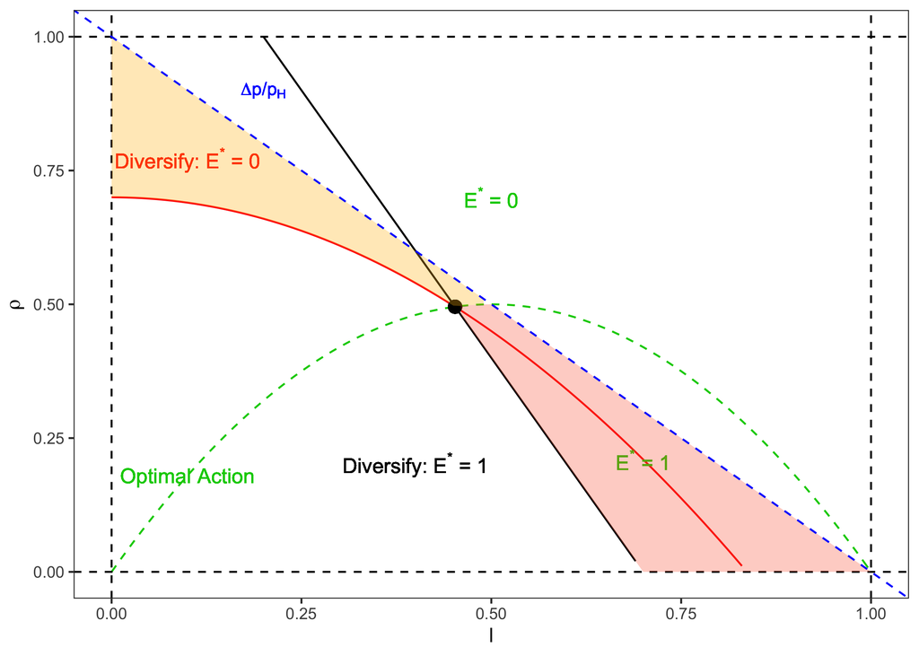

In the above graph, we set $k = 0.2$, the area right of the black line or above the red curve contains all potential characteristics which indicate the entrepreneur to diversify. And within that region, the area above the green dashed curve indicates that the entrepreneur’s optimal action is $E^* = 0$ if the diversification happens. While, the entrepreneur’s optimal action is $E^* = 1$ if the projects’ characteristics are lying below the green dashed curve. If the characteristics of projects are in the yellow region, the entrepreneur will diversify and choose action $E^*=0$. And if the characteristics of projects are in the red region, the entrepreneur will diversify and choose action $E^*=1$. This shows a trade-off between the private benefits and the expected agency rents. However, empirically, the parameter $\rho$ seldomly surpasses maybe 10% and this means the $E^*=1$ will be the more general action after the diversification.

Now let’s see what is the NPV of investors’ investments. With the contract $R_b$ and $E^* = 1$, we have the true expected payoff towards investors as
$$(2R - R_2) p_H p_L + R [p_H (1-p_L) + (1-p_H) p_L] = R \Big ( p_H - p_L
\Big ) + \frac{2 p_L}{p_H} \Big (I-A \Big ),$$
$$\text{and } R \Big ( p_H - p_L \Big ) + \frac{2 p_L}{p_H} \Big (I-A \Big
) \geq 2(I-A) \implies
p_H R \geq 2(I-A).$$

> It is a bit hard to explain the underlying meaning of this inequality

While with contract $R_b$ and $E^* = 0$, we have the true expected payoff towards investors
$$(2R - R_2) p_L^2 + R [2 p_L (1-p_L)] \geq 2 (I-A) \implies p_H R \geq
\frac{p_H + p_L}{p_L} (I-A) > 2(I-A).$$
Therefore, if the true NPV of investors’ investments is negative when $E = 1$, then it must also be negative when $E = 0$. And in the following setup, we only consider the case when $R_b$ brings the true NPV of investors’ investments to negative conditional on $E^*$ and for simplicity, we assume $p_H R \leq 2(I-A)$. And bringing this assumption into the contract $R_b$ and parameter $\rho$, we have
$$R_2 = \frac{2[p_H R - (I-A)]}{p_H^2} \leq \frac{2(I-A)}{p_H^2} \quad
\text{and} \quad B \leq \frac{\Delta p}{p_H} (I-A)$$

##### 1.4 How Do Investors Update Beliefs?

In this section, we analyse how the investors’ belief on the type of the entrepreneur changes at the beginning of period 2, given the signal $X_0$ at the end of period 1. The signal $X_0$ here assumes to be the only accessible information of the project towards investors and we simplify it here to be the outcome of two projects, i.e. $X_0 \in \{2R, R, 0\}$. We define the variable $T \in \{G, B\}$ as the type of the entrepreneur, where $G$ denotes the Good type and $B$ denotes the Bad type. And investors’ belief at the beginning of period 1 is
$$\mathbb{P}(T) = \begin{cases}
q \quad &\text{, if } T = G \\
1-q \quad &\text{, if } T = B,
\end{cases}$$
where $q \geq \bar{q}$ and $\bar{q}$ is a threshold. This threshold $\bar{q}$ is a scaler predetermined by investors and if investors’ subjective probability of the entrepreneur being a Good type is below $\bar{q}$, they will identify the entrepreneur as a Bad type.

And based on our previous assumption that the signal is equivalent to the project outcome in period 1, we have that
$$\mathbb{P}(X_0 | T = G) = \begin{cases}
p_H^2 &\text{, if } X_0 = 2R \\
2 p_H (1-pH) &\text{, if } X_0 = R \\
(1 - p_H)^2 &\text{, if } X_0 = 0.
\end{cases}$$
Therefore, investors can use the Bayes rule to update their beliefs towards the type of the entrepreneur at the beginning of the period 2, before deciding whether to continue to finance the company. And we have
$$\mathbb{P}(T = G | X_0) = \frac{\mathbb{P}(X_0 | T = G) \mathbb{P}(T =
G)}{\mathbb{P}(X_0)}
= \frac{\mathbb{P}(X_0 | T = G) q}{\mathbb{P}(X_0 | T = G) q +
\mathbb{P}(X_0 | T = B) (1-q)}.$$
Specifically, we have
$$\mathbb{P}(T = G | X_0 = 2R) = \frac{p_H^2 q}{p_H^2 q + p_H p_L (1-q)} =
\frac{1}{1 + \frac{p_L}{p_H} \frac{1-q}{q}} > \frac{1}{2},$$
$$\mathbb{P}(T = G | X_0 = R) = \frac{2 p_H (1-p_H) q}{2 p_H (1-p_H) q +
[p_H (1-p_L) + (1-p_H) p_L] (1-q)}$$
$$= \frac{1}{1 + \frac{p_H (1-p_L) + (1-p_H) p_L}{2 p_H (1-p_H)}
\frac{1-q}{q}},$$
$$\mathbb{P}(T = G | X_0 = 0) = \frac{(1-p_H)^2 q}{(1-p_H)^2 q + (1-p_H)
(1-p_L) (1-q)} = \frac{1}{1 + \frac{1-p_L}{1-p_H} \frac{1-q}{q}} >
\frac{1}{2}.$$
In the first equation, as $p_L < p_H$ and $q < 0.5$, $\frac{p_L}{p_H} \frac{1-q}{q} < 1$ and $\mathbb{P}(T = G | X_0 = 2R) > \frac{1}{2}$. In the second equation, it is possible that $\mathbb{P}(T = G | X_0 = R) < \frac{1}{2}$ with $\frac{p_H (1-p_L) + (1-p_H) p_L}{2 p_H (1-p_H)} \frac{1-q}{q} > 1$. And the same logic goes in the third equation that $\mathbb{P}(T = G | X_0 = 0) < \frac{1}{2}$ if $\frac{1-p_L}{1-p_H} \frac{1-q}{q} > 1$. Once the posterior probability drops below the predetermined threshold $\bar{q}$, the entrepreneur will be re-identified as a Bad type by investors. Otherwise, the entrepreneur is still identified as a Good type.

##### 1.5 Financial Constraints for a Bad Type

As shown in section 1.4, investors update their beliefs towards the entrepreneur type by the signal $X_0$. If the investors still identify the entrepreneur as a Good type, this company will continue to be financed and operate in Period 2, same as the case in Period 1. However, if the entrepreneur is identified as a Bad type, i.e. knowing that $\bar{E}=1$, then the company may face financial constraints and we are interested in entrepreneur’s action.

First, we rewrite the optimization problem in the case that investors know the entrepreneur is a Bad type.
$$\max_{R_b(r)} \sum_{r \in \Omega} R_b(r) \mathbf{P}(r | E = 1) + {B}
\quad \text{ s.t. }$$
$$\text{(PC)} \quad \sum_{r \in \Omega} (r - R_b(r)) \mathbf{P}(r | E = 1)
\geq 2 (I - A)$$
$$\text{(IC)} \quad \sum_{r \in \Omega} R_b(r) \mathbf{P}(r | E = 1) + B
\geq
\sum_{r \in \Omega} R_b(r) \mathbf{P}(r | E = 0) + 2B$$
$$\Rightarrow
\sum_{r \in \Omega} R_b(r) \Big(\mathbf{P}(r | E = 1) - \mathbf{P}(r | E
= 0)\Big ) \geq B$$
In this case, if $p_H R + p_L R \leq 2(I-A)$, the company won’t be refinanced given insufficient pledgeable income. So, we consider the case that $p_H R + p_L R > 2(I-A)$. (PC) and (IC) can be further simplified as
$$\sum_{r \in \Omega} r \mathbf{P}(r | E = 1) - 2 (I - A) \geq \sum_{r \in
\Omega} R_b(r) \mathbf{P}(r | E = 1)$$
$$\text{and } \sum_{r \in \Omega} R_b(r) \mathbf{P}(r | E = 1)
\Big(\frac{\mathbf{P}(r | E = 1) - \mathbf{P}(r | E = 0)}{\mathbf{P}(r |
E = 1) }\Big ) = \sum_{r \in \Omega} R_b(r) \mathbf{P}(r | E = 1) L(r|E
= 1) \geq B,$$
where $L(r|E=1) = \frac{\mathbf{P}(r | E = 1) - \mathbf{P}(r | E = 0)}{\mathbf{P}(r | E = 1)}$ is the likelihood ratio.

Without using Lagrangian now, we first can see that the (PC) must bind to maximize the objective function. Then with the limited liability, we can test whether the project can be financed by examining the existence of a contract satisfying the (IC) constraints. Therefore, we can say that the company can receive financing if and only if
$$[p_H R + p_L R - 2(I-A)] L(2R | E = 1) \geq B \quad \text{or} \quad [p_H
R + p_L R - 2(I-A)] L(R | E = 1) \geq B,$$
where
$$L(2R | E = 1) = \frac{p_H p_L - p_L^2}{p_H p_L} = \frac{\Delta
p}{p_H} \quad \text{and}$$
$$L(R | E = 1) = \frac{p_H + p_L - 2 p_H p_L - 2 p_L (1-p_L)}{p_H + p_L -
2 p_H p_L} = \frac{(1-2p_L) \Delta p}{p_L + (1-2p_L) p_H}.$$
So, if $p_L \in (0, \frac{1}{2}]$, $L(2R | E = 0) > L(R | E = 0)$ and the company faces financial constraints if $[p_H R + p_L R - 2(I-A)] \frac{\Delta p}{p_H} < B$. And if $p_L \in (\frac{1}{2}, p_H)$, $L(2R | E = 0) < L(R | E = 0)$ and the company faces financial constraints if $[p_H R + p_L R - 2(I-A)] \frac{\Delta p}{\frac{p_L}{1-2p_L} + p_H} < B$. As we are interested in the case that the entrepreneur faces financial constraints, we further analyse each case:

- $[p_H R + p_L R - 2(I-A)] \frac{\Delta p}{p_H} < B \implies p_L \in (0, \min\{\frac{1}{2}, \tilde{p}\})$, where $\tilde{p} = \frac{-2(I-A) + \sqrt{4(I-A)^2 + 4R[p_h^2 R - 2 p_H (I-A) - p_H B]}}{-2R}$ if $4(I-A)^2 + 4R[p_h^2 R - 2 p_H (I-A) - p_H B] \geq 0$.
- $[p_H R + p_L R - 2(I-A)] \frac{(1-2p_L) \Delta p}{p_L + (1-2p_L) p_H} < B \implies p_L \in (\max\{\frac{1}{2}, \hat{p}\}, p_H)$, where $\hat{p}$ is the bigger root for $[p_H R + p_L R - 2(I-A)] \frac{(1-2p_L) \Delta p}{p_L + (1-2p_L) p_H} = B$ if exists.

> Please note that the exact situation for the second case might be more complex than what is written here.

Conditional on $p_L$, $\tilde{p}$ and $\hat{p}$, it is still possible that the company does not face financial constraints. In this case, the entrepreneur’s expected utility will be $(p_H + p_L) R - 2(I-A) + B$. And we will analyse different incentives for choosing a corporate spin-off, even in the cases that the company still receives external financing when the entrepreneur has been identified as a Bad type.

##### 1.6 Corporate Spin-off or Not?

> Please note that the arguments in the [previous document](https://hongyileoxu.github.io/research/TCP_Project/TCP_Project_Model1.html) are not very rigorous. Although the example is still useful, the arguments and reasonings will be restructured in this section.

The corporate spin-off is defined as the action that breaks the divisions of the parent company into independent businesses and the shareholders of the parent company will receive equivalent shares in the new company, compensating the loss in value of original shares. In other words, the shareholders will have the same proportion of claims to the profits from all new entities, but all entities will have different management teams. And in our setting, we define the corporate spin-off as splitting the company after the diversification into two independent entities, where the first entity contains project $a$ and the second contains project $b$. (“entity” and “project” are interchangeable hereafter) After the spin-off, the entrepreneur will still manage project $a$ and entitle the profits from project $b$, but a new manager will be hired to manage project $b$. Previous assumptions in Period 1 still holds, such that the entrepreneur will provide asset $A$ to each project. In addition, a corporate spin-off will incur an exogenous cost $C$ on the entrepreneur. But for simplicity, we assume $C=0$.

Then we need to consider two cases that the entrepreneur may face at the beginning of Period 2, conditional on the projects she has.

###### Scenario 1

The first case is the company facing financial constraints after the entrepreneur being identified as a Bad type. In this case, if the entrepreneur does not choose to spin off, the company will not be refinanced in Period 2 and the utility for the entrepreneur is $2A$. While if a corporate spin-off is chosen, project $a$ still managed by the entrepreneur will be invested by investors and the entrepreneur can obtain $p_H R - (I-A)$. In addition, project $b$ will have another manager with characteristics $\theta = (p_H', p_L', B')$. Each element corresponds to her probability of success under exerting efforts and shirking and her private benefits and we assume that the characteristics of the new manager is known by all parties in this economy. Since the manager is chosen by the entrepreneur, we know the manager’s characteristic $\theta^*$ must be
$$\theta^* = \arg \max_{\theta} f(\theta), \text{ where } f(\theta) =
p_H' R - (I-A) - p_H' \frac{B'}{\Delta p'} \text{ and }
\Delta p' = p_H' - p_L',$$
and project $b$’s expected payoff towards the entrepreneur is $f(\theta^*)$. So, the total payoff towards the entrepreneur, conditional on both projects being financed, is $p_H R - (I-A) + f(\theta^*)$. We then compare this payoff with the payoff from only operating project $a$, which equals to $p_H R - I + 2A > 2A$ and conclude that

1. if $p_H R - (I-A) + f(\theta^*) \geq p_H R - I + 2A$, the entrepreneur will choose a corporate spin-off;
2. if $p_H R - I + 2A > p_H R - (I-A) + f(\theta^*)$, the entrepreneur will choose a divestment rather than a corporate spin-off. More specifically, she will sell/terminate project $b$ and only manage project $a$, given that project $b$ will only proceed if it can generate nonnegative returns to the entrepreneur (shareholders).

In all, either a corporate spin-off or a divestment will make the entrepreneur better off.

###### Scenario 2

The second case is the company not facing financial constraints even after the entrepreneur being identified as a Bad type. Then the entrepreneur’s objective function from managing the company is $(p_H + p_L) R - 2(I-A) + B \geq 2A$. Conditional on the necessary condition for diversification in [1.2 When Does the Entrepreneur Choose to Diversify?], we know that
$$p_H R - I + 2A \leq p_H p_L R_2 + B = 2 p_L R + B - 2(I-A) < (p_H +
p_L) R + B - 2(I-A).$$
This means that divestment is always suboptimal in this case. We next compare this with the payoff from a corporate spin-off and find that the entrepreneur will choose a spin-off if
$$(p_H + p_L) R - 2(I-A) + B < p_H R - (I-A) + f(\theta^*) = (p_H +
p_H') R - 2(I-A) - p_H' \frac{B'}{\Delta p'}$$
$$\implies (p_H' - p_L) R - p_H' \frac{B'}{\Delta p'} - B
\geq 0$$
To satisfy this condition, generally speaking, the new manager hired by the entrepreneur must have $p_H' > p_L$ and relatively small agency rents. And the above condition tells us the entrepreneur will choose a corporate spin-off only if the marginal benefits from operating project $b$ separately overweight the private benefit $B$.

> Please note that since investors are risk-neutral and competitive, they don’t really care about the risk as long as they can at least break even.

Furthermore, based on the literature, e.g. [Chemmanur and Yan (2004)](https://www.sciencedirect.com/science/article/pii/S0304405X03002411?casa_token=bj566NyqcI4AAAAA:H_th8MMuM1mvPVbzmd0vqstbwr-zozQhdMjc-HEyw3Mt7Nw8dIGrJZSyWHKOlSioBVLOWhG1bw#BIB7), we know that long-term abnormal returns exist if the projects created by corporate spin-offs are taken over. The chain of logic is very simple in this case. From the above analysis, we know that the only channel for the entrepreneur to continue to benefit from project $b$’s operation is to hire a new manager, maximizing the expected residual payoff towards the entrepreneur. However, this does not mean the entrepreneur will bring in the manager maximizing the NPV of project $b$. Therefore, for other asset holders in the market, if they can create a higher NPV by managing project $b$, it will be a great incentive for they to conduct a takeover and deliever abnormal return in the long run, simply because they are better entrepreneurs.

##### 1.7 Conclusion and Extensions

In this document, we develop a model to explain the incentive for corporate spin-offs using the limited ability of the entrepreneur. By introducing this adverse selection into the original moral hazard framework, we show that the Bad type entrepreneur will choose a spin-off when she has been identified as a Bad type by investors. Such an action can produce a higher utility to the entrepreneur. Some may criticize in our setting, investors may not identify the entrepreneur as a Good or Bad type, but incorporate their subjective beliefs into the (PC) and (IC) constraints. This, however, does not alter the logic we presented in this parsimonious model.

Meanwhile, we only consider project $a$ and $b$ operating for one period and two projects will restart in the second period. And the entrepreneur cannot move assets across periods and the operation outcomes from two projects affect nothing but the investors identification process. This is clearly not an accurate assumption, as most corporations will operate across several periods. But these extensions need a different setting with continuous cash flow outcome rather than the binary outcome here. So, at the current stage, any suggestions and advices are welcome and appreciated.

##### 1.8 Appendix

###### Sequence of events in a spin-off (sample)

Graph Source: [Link](https://stackoverflow.com/questions/7492274/draw-a-chronological-timeline-with-ggplot2) / [Latex](https://tikz.net/timeline/)

[output not shown]

[output not shown]

[output not shown]

[figure not shown]